# Reproducible Research Project 1

Thu Pham

11/12/2020

## Introduction

It is now possible to collect a large amount of data about personal movement using activity monitoring devices such as a Fitbit, Nike Fuelband, or Jawbone Up. These type of devices are part of the “quantified self” movement – a group of enthusiasts who take measurements about themselves regularly to improve their health, to find patterns in their behavior, or because they are tech geeks. But these data remain under-utilized both because the raw data are hard to obtain and there is a lack of statistical methods and software for processing and interpreting the data.

This assignment makes use of data from a personal activity monitoring device. This device collects data at 5 minute intervals through out the day. The data consists of two months of data from an anonymous individual collected during the months of October and November, 2012 and include the number of steps taken in 5 minute intervals each day.

## 1. Loading and preprocessing the data

#### Load the data

```r
unzip("./repdata_data_activity.zip", exdir = "data")
data <- read.csv("data/activity.csv")
head(data)
```

```
##   steps       date interval
## 1    NA 2012-10-01        0
## 2    NA 2012-10-01        5
## 3    NA 2012-10-01       10
## 4    NA 2012-10-01       15
## 5    NA 2012-10-01       20
## 6    NA 2012-10-01       25
```

```r
str(data)
```

```
## 'data.frame':    17568 obs. of  3 variables:
##  $ steps   : int  NA NA NA NA NA NA NA NA NA NA ...
##  $ date    : chr  "2012-10-01" "2012-10-01" "2012-10-01" "2012-10-01" ...
##  $ interval: int  0 5 10 15 20 25 30 35 40 45 ...
```

#### Process/transform the data into a format suitable for the analysis

```r
data$date <- as.Date(data$date)
```

## 2. What is mean total number of steps taken per day?

#### Aggregate() function for the sum of the total steps per day

```r
daily_steps <- aggregate(steps ~ date, data, sum, na.rm = TRUE)
head(daily_steps,6)
```

```
##         date steps
## 1 2012-10-02   126
## 2 2012-10-03 11352
## 3 2012-10-04 12116
## 4 2012-10-05 13294
## 5 2012-10-06 15420
## 6 2012-10-07 11015
```

#### Histogram for “Total Number Of Steps Taken Per Day”

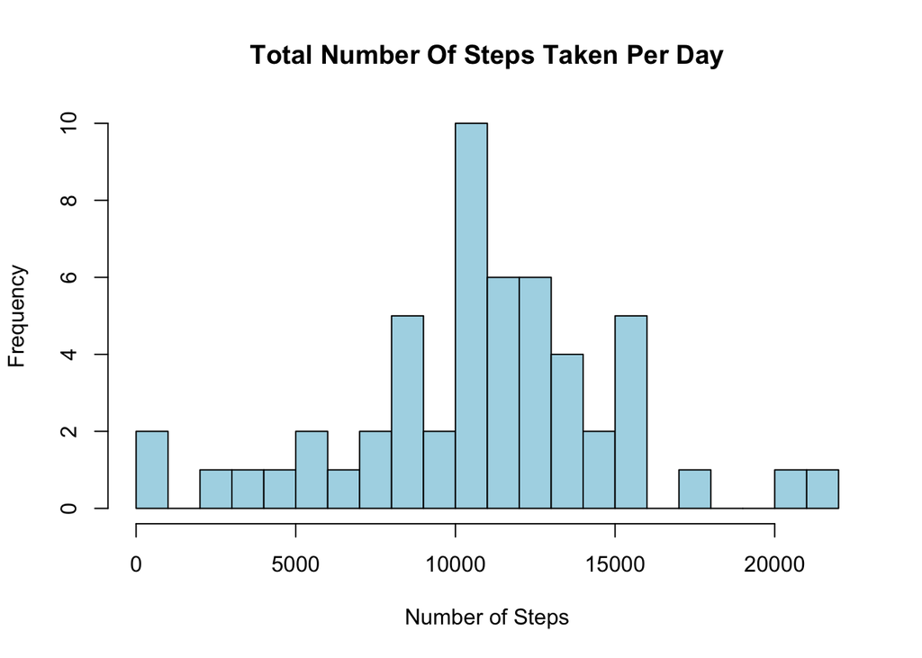

```r
hist(daily_steps$steps, breaks = 30, main = paste("Total Number Of Steps Taken Per Day"), col="lightblue",xlab="Number of Steps")
```

#### Mean

```r
mean(daily_steps$steps, na.rm = FALSE)
```

```
## [1] 10766.19
```

#### Median

```r
median(daily_steps$steps, na.rm = FALSE)
```

```
## [1] 10765
```

## 3. What is the average daily activity pattern?

#### Average number of steps per interval

```r
activity_time_series <- aggregate(data$steps, by = list(data$interval),mean, na.rm = TRUE)
colnames(activity_time_series) <- c("interval", "steps")
head(activity_time_series, 6)
```

```
##   interval     steps
## 1        0 1.7169811
## 2        5 0.3396226
## 3       10 0.1320755
## 4       15 0.1509434
## 5       20 0.0754717
## 6       25 2.0943396
```

##### Plot Average Number of Steps per Interval

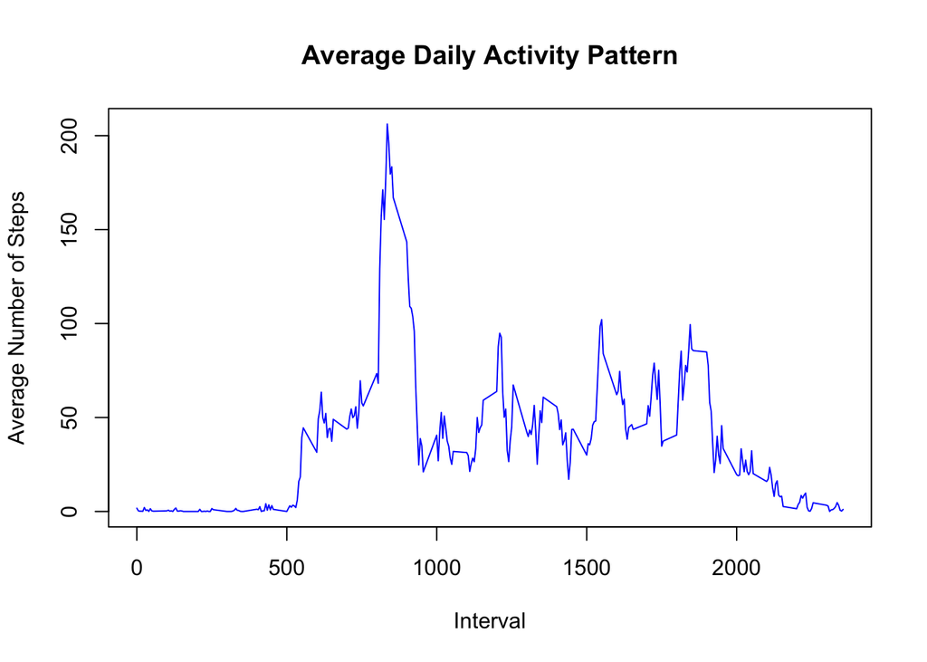

```r
plot(activity_time_series$interval, activity_time_series$steps, type="l",
     xlab = "Interval", ylab = "Average Number of Steps", main = "Average Daily Activity Pattern",  col ="blue")
```

#### Which 5-minute interval contains the maximum number of steps?

```r
max_interval <- activity_time_series[which.max(activity_time_series$steps),]
max_interval
```

```
##     interval    steps
## 104      835 206.1698
```

## 4. Imputing missing values

###### Note that there are a number of days/intervals where there are missing values (coded as NA). The presence of missing days may introduce bias into some calculations or summaries of the data.

#### 4.1 Calculate and report the total number of missing values in the dataset

```r
missingvalue <- sum(is.na(data$steps))
missingvalue
```

```
## [1] 2304
```

#### 4.3 Create a new dataset that is equal to the original dataset but with the missing data filled in

```r
library(Hmisc)
imputed_data <- data
imputed_data$steps <- impute(data$steps, fun=mean)
head(imputed_data,6)
```

```
##     steps       date interval
## 1 37.3826 2012-10-01        0
## 2 37.3826 2012-10-01        5
## 3 37.3826 2012-10-01       10
## 4 37.3826 2012-10-01       15
## 5 37.3826 2012-10-01       20
## 6 37.3826 2012-10-01       25
```

```r
sum(is.na(imputed_data$steps))
```

```
## [1] 0
```

#### 4.4 Make a histogram of the total number of steps taken each day and Calculate and report the mean and median total number of steps taken per day.

```r
daily_steps2 <- aggregate(steps ~ date, imputed_data, sum, na.rm = TRUE)
head(daily_steps2,6)
```

```
##         date    steps
## 1 2012-10-01 10766.19
## 2 2012-10-02   126.00
## 3 2012-10-03 11352.00
## 4 2012-10-04 12116.00
## 5 2012-10-05 13294.00
## 6 2012-10-06 15420.00
```

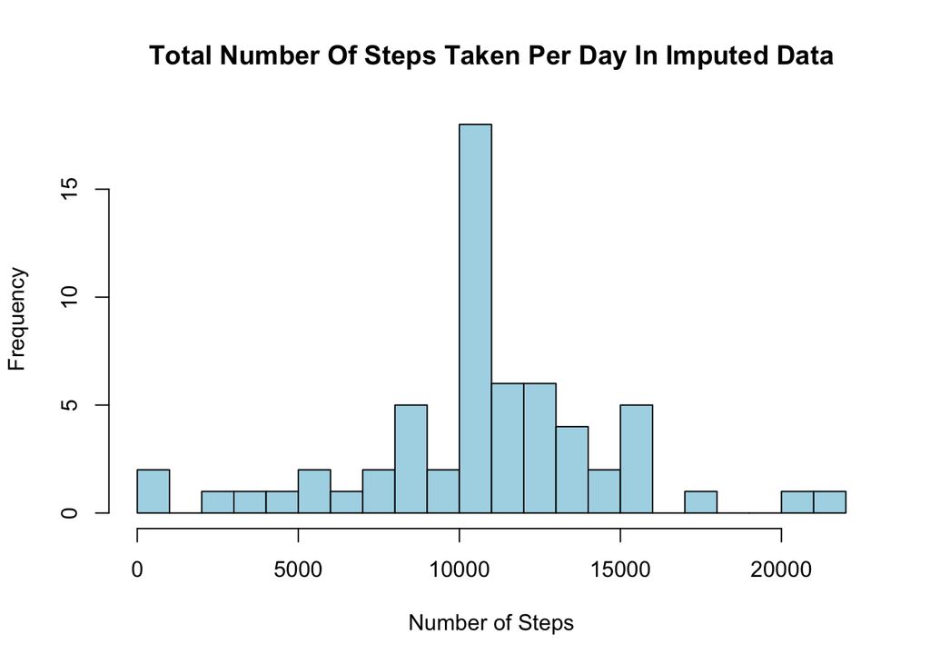

```r
hist(daily_steps2$steps, breaks = 30, main = paste("Total Number Of Steps Taken Per Day In Imputed Data"), col="lightblue",xlab="Number of Steps")
```

```r
mean(daily_steps2$steps, na.rm = FALSE)
```

```
## [1] 10766.19
```

```r
median(daily_steps2$steps, na.rm = FALSE)
```

```
## [1] 10766.19
```